# HTG_vignette

# DETAILED TUTURAL

This is a detailed tutorial to guide you through the usage of the ‘HTGAnalyzer’ package. The first step is to load the library:

[output not shown]

## HTG technology:

### HTG_auto() for HTG:

We will start explaining the function `HTG_auto`. This function was designed to simplify the process of performing multiple analyses on HTG data. It has a lot of variables that can be turned on and off to skip an analysis if you wanted or also the function has a lot of variables in case you want to change the stablished threshold that we propose.

You can download the example Excel files from the following link: https://github.com/ISGLOBAL-Rakislova-Lab/HTGAnalyzer/tree/main/SUPLEMENTARY_OUTPUT

#### HTG_auto(): All the analysis for HTG:

Imagine you have HTG data and want to perform a comprehensive set of analyses, including Differential Expression Analysis (DEA), Tumor Microenvironment (TME) analysis, Survival Analysis, and Gene Set Enrichment Analysis (GSEA).

The code below demonstrates how to conduct each of these analyses. We’ve highlighted all the variables that can be modified in the functions, just to make you aware of them, but feel free to leave them unchanged if they suit your needs.

```r
result <- HTG_auto(
  counts_file_path = "~/HTGAnalyzer/counts.xlsx",  # path to counts data
  file_type = "HTG",  # Type of file
  AnnotData_file_path = "~/HTGAnalyzer/annotdata.xlsx",  # path to annotdata.
  pattern = "^NC-|^POS-|^GDNA-|^ERCC-",  # HTG probes that start with one of these prefixes
  # this thresholds are stablish for HTG transcriptomic panel.
  threshold_superior_pos = 5,
  threshold_line_pos = 4,
  threshold_inferior_lib = 5e+06,
  threshold_lib = 7e+06,
  threshold_superior_nc = 0.05,
  threshold_line_nc = 0.045,
  threshold_superior_gdna = 0.025,
  threshold_line_gdna = 0.02,
  threshold_superior_ercc = 0.03,
  threshold_line_ercc = 0.025,
  threshold_inferior_median = 3,
  threshold_line_median = 5,
  save_csv = TRUE,
  csv_file = "QC_results.csv",
  design_formula = "HPV_status",
  percentage_gene = 0.2,
  threshold_gene = 200,
  threshold_subject = 10,
  genes_to_use = c("CCND1", "MMP10", "CTTN"), # Genes used for survival analysis (if you turn NULL it will use the top 10 genes of differential expression. )
  heatmap_columns = c("HPV_status", "Ciclina_D1"),  # Columns for the heatmap
  contrast = c("HPV_status", "Positive", "Negative"),  # Contrast for differential expression analysis
  pCutoff = 5e-2,
  variable_01 = "Recurrence_01",   # Variable for survival analysis
  time = "Time_to_death_surv",  # Time for survival analysis
  # Analysis that can be performed.
  DEA = TRUE,
  remove_outliers = TRUE,
  GSEA = TRUE,
  generate_heatmap = TRUE,
  TME = TRUE,
  survival_analysis = TRUE
)
```

The code above is an example. Some of the parameters have default values in the function, but they are included here for clarity. Refer to the function documentation for more details on each parameter.

#### HTG_auto(): skipping an analysis for HTG:

If you want to perform some analyses but exclude others (e.g., skipping survival analysis and GSEA), you can set the relevant parameter to FALSE. Below is an example where survival and GSEA analyses are excluded:

If an analysis requires a specific column that you don’t have (e.g., survival analysis needs the variable_01 and time columns), you can set those variables to NULL to skip that particular analysis.

```r
## LET'S SKIP survival analysis and GSEA

result <- HTG_auto(
  counts_file_path = "~/HTGAnalyzer/counts.xlsx",  # Path to counts data
  file_type = "HTG",  # Type of file
  AnnotData_file_path = "~/HTGAnalyzer/annotdata.xlsx",  # Path to annotation data
  pattern = "^NC-|^POS-|^GDNA-|^ERCC-",  # HTG probes that start with one of these prefixes
  # These thresholds are specific for the HTG transcriptomic panel
  threshold_superior_pos = 5,
  threshold_line_pos = 4,
  threshold_inferior_lib = 5e+06,
  threshold_lib = 7e+06,
  threshold_superior_nc = 0.05,
  threshold_line_nc = 0.045,
  threshold_superior_gdna = 0.025,
  threshold_line_gdna = 0.02,
  threshold_superior_ercc = 0.03,
  threshold_line_ercc = 0.025,
  threshold_inferior_median = 3,
  threshold_line_median = 5,
  save_csv = TRUE,
  csv_file = "QC_results.csv",
  design_formula = "HPV_status",
  percentage_gene = 0.2,
  threshold_gene = 200,
  threshold_subject = 10,
  genes_to_use = c("CCND1", "MMP10", "CTTN"),  # Genes used for survival analysis (optional)
  heatmap_columns = c("HPV_status", "Ciclina_D1"),
  contrast = c("HPV_status", "Positive", "Negative"),  # Contrast for differential analysis
  pCutoff = 5e-2,
  variable_01 = "Recurrence_01",  # Variable for survival analysis
  time = "Time_to_death_surv",  # Time for survival analysis
  DEA = TRUE,
  remove_outliers = TRUE,
  GSEA = FALSE,
  generate_heatmap = TRUE,
  TME = TRUE,
  survival_analysis = FALSE  # Skip survival analysis by setting this parameter to FALSE
)
```

In this example, survival analysis is skipped by setting `survival_analysis = FALSE`and GSA by setting `GSEA = FALSE`. The output will indicate that the survival analysis step has been skipped.

### STEP BY STEP for HTG:

What if you already had some analysis or you want to get more control over it? Don’t worry we have the solution.Let’s go `step-by-step`, starting with data import:

#### Load data: HTG_import_counts() for HTG:

You can upload data directly from HTG Edge Reveal using this format. R needs a quadratic information structure, so maybe you will have to edit your data to look like this on excel before importing:

| **id** | patient_1 | patient_2 | patient_3 | patient_4 | patient_5 | patient_6 | patient_7 | patient_8 |
| --- | --- | --- | --- | --- | --- | --- | --- | --- |
| **Sample ID** | 1 | 2 | 3 | 4 | 5 | 6 | 7 | 8 |
| **Well** | A1 | B1 | C1 | D1 | E1 | F1 | G1 | H1 |
| **Date Parsed** | 14/08/2024 | 14/08/2024 | 14/08/2024 | 14/08/2024 | 14/08/2024 | 14/08/2024 | 14/08/2024 | 14/08/2024 |
| **Total Counts** | 9650628 | 33950226 | 24680689 | 10605963 | 7395173 | 4057094 | 20049502 | 13607678 |
| **A3GALT2** | 0 | 0 | 164 | 19 | 46 | 1 | 0 | 0 |
| **A4GALT** | 2 | 662 | 665 | 830 | 748 | 89 | 256 | 333 |
| **A4GNT** | 0 | 1041 | 103 | 0 | 0 | 2 | 0 | 0 |
| **AAAS** | 0 | 368 | 70 | 634 | 707 | 425 | 587 | 872 |
| **AACS** | 1 | 0 | 562 | 728 | 250 | 209 | 365 | 445 |
| **AADAC** | 0 | 382 | 0 | 5 | 144 | 0 | 0 | 1 |

Or an alternative format:

| **id** | patient_10 | patient_11 | patient_5 | patient_6 | patient_4 | patient_1 | patient_2 | patient_3 | patient_7 | patient_9 | patient_8 |
| --- | --- | --- | --- | --- | --- | --- | --- | --- | --- | --- | --- |
| **A3GALT2** | 0 | 0 | 164 | 19 | 46 | 1 | 0 | 0 | 0 | 0 | 0 |
| **A4GALT** | 2 | 662 | 665 | 830 | 748 | 89 | 256 | 333 | 210 | 2 | 504 |
| **A4GNT** | 0 | 1041 | 103 | 0 | 0 | 2 | 0 | 0 | 84 | 0 | 0 |
| **AAAS** | 0 | 368 | 70 | 634 | 707 | 425 | 587 | 872 | 542 | 0 | 370 |
| **AACS** | 1 | 0 | 562 | 728 | 250 | 209 | 365 | 445 | 62 | 46 | 785 |
| **AADAC** | 0 | 382 | 0 | 5 | 144 | 0 | 0 | 1 | 260 | 683 | 77 |

```r
## LOAD COUNTS DATA

htg_data <- HTG_import_counts("~/HTGAnalyzer/counts.xlsx", "HTG")
head(htg_data)

## LOAD ANNOTDATA
annotdata<- readxl::read_excel("~/HTGAnalyzer/annotdata.xlsx")
head(annotdata)
```

**NOTE:** For the following functions, we’ll use tutorial data from the package. If you want to try with your data, replace `counts_data_tutorial` with `htg_data`.

#### HTG_quant_to_qual() for HTG:

If you need to transform a quantitative column to a qualitative one, you can use this function.

```r
head(AnnotData_tutorial)
```

```
#>                  id HPV_status Ciclina_D1 FIGO_2021_STAGE Recurrence
#> pacient_1 pacient_1   Positive         10            IIIB        yes
#> pacient_2 pacient_2   Positive         50              II         no
#> pacient_3 pacient_3   Positive         NA            IIIC         no
#> pacient_4 pacient_4   Positive          0              IB        yes
#> pacient_5 pacient_5   Negative         50              IB        yes
#> pacient_6 pacient_6   Negative         80              IB         no
#>           Recurrence_01 Time_to_death_surv
#> pacient_1             1               1287
#> pacient_2             0                510
#> pacient_3             0                762
#> pacient_4             1               1164
#> pacient_5             1               5844
#> pacient_6             0               1436
```

```r
AnnotData_tutorial <- HTG_quant_to_qual(AnnotData_tutorial,  # Dataset to modify
                                        "Ciclina_D1",  # Column to transform
                                        60,  # Threshold to categorize the data
                                        "high",  # Value for entries greater than 60
                                        "low")  # Value for entries less than 60
#Last column will be the generated one
head(AnnotData_tutorial)
```

```
#>                  id HPV_status Ciclina_D1 FIGO_2021_STAGE Recurrence
#> pacient_1 pacient_1   Positive         10            IIIB        yes
#> pacient_2 pacient_2   Positive         50              II         no
#> pacient_3 pacient_3   Positive         NA            IIIC         no
#> pacient_4 pacient_4   Positive          0              IB        yes
#> pacient_5 pacient_5   Negative         50              IB        yes
#> pacient_6 pacient_6   Negative         80              IB         no
#>           Recurrence_01 Time_to_death_surv Ciclina_D12
#> pacient_1             1               1287         low
#> pacient_2             0                510         low
#> pacient_3             0                762        <NA>
#> pacient_4             1               1164         low
#> pacient_5             1               5844         low
#> pacient_6             0               1436        high
```

```r
head(AnnotData_tutorial$Ciclina_D12)
```

```
#> [1] "low"  "low"  NA     "low"  "low"  "high"
```

#### HTG_subset() for HTG:

Now that you have the counts data loaded, you can search for certain genes of interest, look for specific probes, or filter results from DEA. This function can also normalize the data by TPM (Transcripts Per Million).

```r
# Subset rows with the prefix "ERCC"
cts_ERCC <- HTG_subset(counts_data_tutorial, "ERCC")
```

```
#> Subsetting without normalization...
#> Dimensions: 101 11
```

```r
# Subset rows with the prefix "POS"
cts_POS <- HTG_subset(counts_data_tutorial, "POS")
```

```
#> Subsetting without normalization...
#> Dimensions: 5 11
```

```r
 # Subset rows with the prefix "NC"
cts_NC <- HTG_subset(counts_data_tutorial, "NC")
```

```
#> Subsetting without normalization...
#> Dimensions: 146 11
```

```r
# Subset rows with the prefix "GDNA"
cts_GDNA <- HTG_subset(counts_data_tutorial, "GDNA")
```

```
#> Subsetting without normalization...
#> Dimensions: 22 11
```

```r
# Subset rows with the prefix "ZZZ3"
cts_ZZZ3 <- HTG_subset(counts_data_tutorial, "ZZZ3")
```

```
#> Subsetting without normalization...
#> Dimensions: 1 11
```

```r
# Subset rows with the prefix "ZZZ3" and normalize the data
cts_ZZZ3 <- HTG_subset(counts_data_tutorial, "ZZZ3", normalize = TRUE)
```

```
#> Normalizing data using TPM (Transcripts Per Million)...
#> Dimensions: 1 11
```

```r
resAAAS<- HTG_subset(res_tutorial, "AAAS")
```

```
#> Subsetting without normalization...
#> Dimensions: 1 5
```

#### Perform a QC: HTG_QC() for HTG:

Now, let’s perform quality control (QC) on the tutorial data. As you may know, HTG uses specific probes to perform QC to detect outliers and assess data quality. Default thresholds are provided, but feel free to adjust them. This function will:

1. Detect outliers and save them in an object called `outliers`.
2. Generate visualization plots.
3. Perform summary statistics and save them in a .csv file.
4. Generate a table with the QC results for further review.

```r
outliers <- HTG_QC(counts_data_tutorial, pattern = "^NC-|^POS-|^GDNA-|^ERCC-",
                             threshold_superior_pos = 5,
                             threshold_line_pos = 4,
                             threshold_inferior_lib = 5e+06,
                             threshold_lib = 7e+06,
                             threshold_superior_nc = 0.05,
                             threshold_line_nc = 0.045,
                             threshold_superior_gdna = 0.025,
                             threshold_line_gdna = 0.02,
                             threshold_superior_ercc = 0.03,
                             threshold_line_ercc = 0.025,
                             threshold_inferior_median = 3,
                             threshold_line_median = 5,
                             save_csv = TRUE,
                             csv_file = "QC_results.csv")
```

```
#> INITIATING DATA FILTERING...
#> Summary statistics saved as 'summary_stats.csv'
#> INITIATING QC PLOTS...
#> QC DATA SAVED AS ' QC_results.csv '
#> 'data.frame':    11 obs. of  12 variables:
#>  $ total_POS : num  3347486 32239 214604 31934 68866 ...
#>  $ total_GDNA: num  2372 17785 1598 146 884 ...
#>  $ total_gens: num  10584447 14623894 12201950 12851088 13477128 ...
#>  $ total_NC  : num  13712 274 2738 393 3034 ...
#>  $ total_ERCC: num  3580 186 1523 236 1355 ...
#>  $ pos/gens  : num  31.626 0.22 1.759 0.248 0.511 ...
#>  $ gdna/gens : num  0.02241 0.12162 0.0131 0.00114 0.00656 ...
#>  $ nc/gens   : num  0.12955 0.00187 0.02244 0.00306 0.02251 ...
#>  $ ERCC/gens : num  0.03382 0.00127 0.01248 0.00184 0.01005 ...
#>  $ median    : num  0 503 131 126 167 69 139 189 73 0 ...
#>  $ samples   : chr  "pacient_10" "pacient_11" "pacient_5" "pacient_6" ...
#>  $ Size      : num  10584447 14623894 12201950 12851088 13477128 ...
#> Warning: Ensembl will soon enforce the use of https.
#> Ensure the 'host' argument includes "https://"
#> >>>--- This function is being optimised and we strongly recommend that you should set `source` as `local`....
#> Warning in IOBR::count2tpm(counts_data, idType = "Symbol", org = "hsa", :
#> >>>--- Omit 1292 genes of which length is not available !
#>         Sample          Gene                TPM              LogTPM
#>  pacient_10:17404   Length:191444      Min.   :  0.000   Min.   :0.0000
#>  pacient_11:17404   Class :character   1st Qu.:  0.000   1st Qu.:0.0000
#>  pacient_5 :17404   Mode  :character   Median :  1.324   Median :0.8435
#>  pacient_6 :17404                      Mean   :  9.835   Mean   :1.2884
#>  pacient_4 :17404                      3rd Qu.:  9.279   3rd Qu.:2.3302
#>  pacient_1 :17404                      Max.   :229.169   Max.   :5.4388
#>  (Other)   :87020
#>    Threshold
#>  Min.   :3.931
#>  1st Qu.:4.512
#>  Median :4.616
#>  Mean   :4.660
#>  3rd Qu.:4.825
#>  Max.   :5.439
#>
#> Violin plot saved as 'QC_plots_violin_plot.pdf'
#> QC plots saved as 'plot_QC.pdf'
#> Heatmap PLOTS SAVED AS 'HTG_QC_heatmap.pdf'
#>                               ***
#> These are the samples plotted at least once in the heatmap:
#> The number of samples that are outliers are: 3pacient_10 pacient_11 pacient_9
```

#### HTG_calculate_summary_stats() for HTG:

If you only want to perform the summary statistics without full QC, this function will generate summary stats and save them in a .csv file as well as an R object.

```r
summary <- HTG_calculate_summary_stats(counts_data_tutorial, pattern = "^NC-|^POS-|^GDNA-|^ERCC-")
```

#### Perform all the analysis: HTG_analysis() for HTG:

Now that you know which samples are outliers, you can perform any of the analyses. This function will remove the outliers, perform DEA, TME, survival analysis, and GSEA. If you want to perform each step separately, you can use the functions `HTG_GSEA()`, `HTG_DEA()`, `HTG_TME()`, and `HTG_survival()`. Running the analyses individually offers greater control, allowing you to adjust additional parameters. Refer to each function’s section for detailed instructions on how they work.

```r
ALL_done <- HTG_analysis(outliers = outliers_tutorial,
                         pattern = "^NC-|^POS-|^GDNA-|^ERCC-",
                         counts_data = counts_data_tutorial,
                         col_data = AnnotData_tutorial,
                         design_formula = "HPV_status",
                         percentage_gene = 0.2,
                         threshold_gene = 200,
                         threshold_subject = 10,
                         genes_to_use = c("CCND1", "MMP10", "CTTN"),
                         heatmap_columns = c("HPV_status","Ciclina_D1"),
                         contrast = c("HPV_status", "Positive", "Negative"),
                         pCutoff = 5e-2,
                         variable_01 = "Recurrence_01",
                         time = "Time_to_death_surv",
                         DEA = TRUE,
                         remove_outliers = TRUE,
                         GSEA = FALSE,
                         generate_heatmap = TRUE,
                         TME = TRUE,
                         survival_analysis = FALSE)
```

```
#> FILTERING THE COUNT DATA. DELETING THE PROVES...
#> REMOVING OUTLIERS...
#> STARTING THE DIFERENTIAN EXPRESSION ANALYSIS.
#>
#> BEFORE FILTERING
#> class: DESeqDataSet
#> dim: 19394 8
#> metadata(1): version
#> assays(1): counts
#> rownames(19394): A3GALT2 A4GALT ... ZZEF1 ZZZ3
#> rowData names(0):
#> colnames(8): pacient_1 pacient_2 ... pacient_7 pacient_8
#> colData names(8): id HPV_status ... Time_to_death_surv Ciclina_D12
#>
#>
#> AFTER FILTERING
#> class: DESeqDataSet
#> dim: 10293 8
#> metadata(1): version
#> assays(1): counts
#> rownames(10293): A4GALT AAAS ... ZZEF1 ZZZ3
#> rowData names(0):
#> colnames(8): pacient_1 pacient_2 ... pacient_7 pacient_8
#> colData names(8): id HPV_status ... Time_to_death_surv Ciclina_D12
#>
#> RESULTS OF VST NORMALIZATION
#> class: DESeqTransform
#> dim: 10293 8
#> metadata(1): version
#> assays(1): ''
#> rownames(10293): A4GALT AAAS ... ZZEF1 ZZZ3
#> rowData names(4): baseMean baseVar allZero dispFit
#> colnames(8): pacient_1 pacient_2 ... pacient_7 pacient_8
#> colData names(9): id HPV_status ... Ciclina_D12 sizeFactor
#>
#> HEATMAP
#> GENERATING HEATMAP
#> GENERATING CONTRAST RESULTS
#> SUMMARY OF RESULT OF THE CONTRAST
#> [1] "DESeqResults object of length 6 with 2 metadata columns"
```

[output cut: 138 more lines]

```
#>    <chr>                            <chr>    <dbl>
#>  1 Myeloid_dendritic_cell_activated t-test  0.308
#>  2 B_cell                           t-test  0.0483
#>  3 T_cell_CD4+_memory               t-test  0.219
#>  4 T_cell_CD4+_naive                t-test  0.196
#>  5 T_cell_CD4+_(non-regulatory)     t-test  0.391
#>  6 T_cell_CD4+_central_memory       t-test  0.760
#>  7 T_cell_CD4+_effector_memory      t-test  0.182
#>  8 T_cell_CD8+_naive                t-test  0.170
#>  9 T_cell_CD8+                      t-test  0.0164
#> 10 T_cell_CD8+_central_memory       t-test  0.0148
#> # ℹ 29 more rows
#> GENERATING HEATMAPS
#> Heatmap of qti, EPIC and xcell will be stored on plots_TME_heatmap.pdf
#> Skipping survival analysis.
```

#### Differentia expression analysis: HTG_DEA() for HTG:

If you want more control, such as applying extra filtering or performing LFC shrinkage, `HTG_DEA()` will provide more options.

[output not shown]

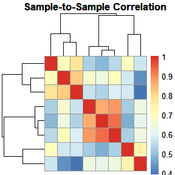

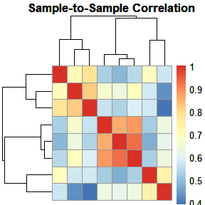

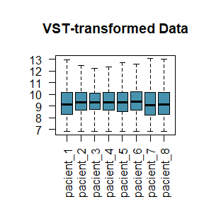

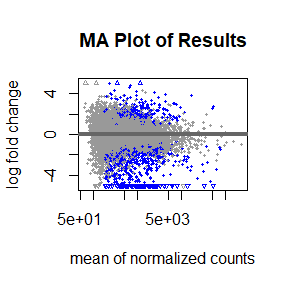

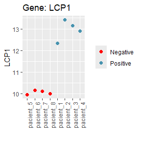

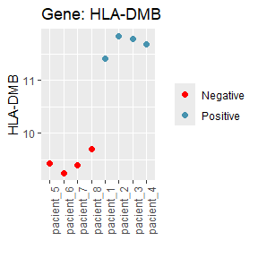

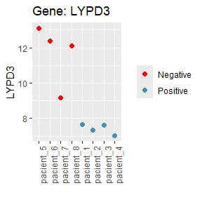

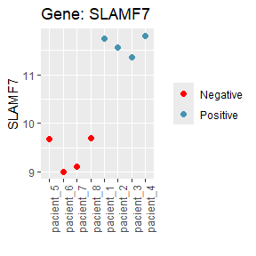

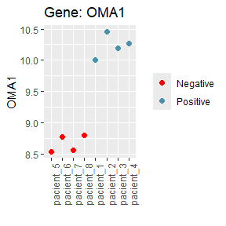

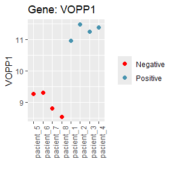

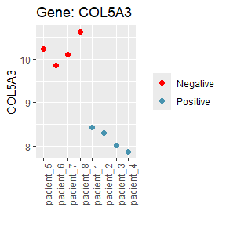

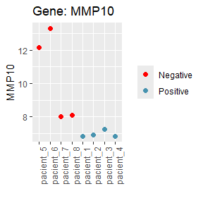

[1 more figures not shown]

```r
### DEA:
results <- HTG_DEA(outliers= outliers_tutorial,
                   counts_data= counts_data_tutorial,
                   AnnotData_tutorial,
                   design_formula = "HPV_status",
                   heatmap_columns = c("HPV_status", "Recurrence"),
                   contrast = c("HPV_status", "Positive", "Negative"),
                   pattern = "^NC-|^POS-|^GDNA-|^ERCC-",
                   remove_outliers = TRUE,
                   percentage_gene = 0.2,
                   threshold_gene = 200,
                   threshold_subject = 10,
                   pCutoff = 5e-2,
                   apply_filtering = TRUE,
                   apply_lfc_shrinkage = TRUE,
                   extract_shrinkage = FALSE)
```

```r
head(results)
```

```
#> log2 fold change (MLE): HPV_status Positive vs Negative
#> Wald test p-value: HPV status Positive vs Negative
#> DataFrame with 6 rows and 6 columns
#>         baseMean log2FoldChange     lfcSE      stat    pvalue      padj
#>        <numeric>      <numeric> <numeric> <numeric> <numeric> <numeric>
#> A4GALT   438.986      -1.168110  0.681001  -1.71528 0.0862932  0.359868
#> AAAS     485.090       0.116866  0.677368   0.17253 0.8630209  0.956719
#> AACS     412.853      -1.235671  0.703735  -1.75587 0.0791098  0.344581
#> AAGAB   1116.256      -0.588542  0.392074  -1.50110 0.1333298  0.447444
#> AAK1     744.302       1.111361  0.653029   1.70185 0.0887826  0.365751
#> AAMDC    212.438      -1.218840  0.649871  -1.87551 0.0607224  0.294947
```

#### GSEA: GSEA() for HTG:

A GSEA analysis can be performed using the results from the DEA contrast. HTG_GSEA will generate plots and Excel files for easy interpretation.

```r
HTG_GSEA(res_tutorial)
```

[output not shown]

[output cut: 59 more lines]

[output not shown]

#### TME: HTG_TME () for HTG:

This function performs Tumor Microenvironment (TME) analysis, which will be stored in `TME_results`. You can access each method using `$`. This object contains results from three methodologies.

```r
TME_results<- HTG_TME(outliers= outliers_tutorial,
                      pattern= "^NC-|^POS-|^GDNA-|^ERCC-",
                      counts_data= counts_data_tutorial,
                      AnnotData= AnnotData_tutorial,
                      design_formula= "HPV_status",
                      remove_outliers = TRUE,
                      DEA = NULL)
```

```
#> [1] "Inicial gene number: 19394"
#> TPM normalization performed and stored on tpm_counts.csv
#> >>>--- This function is being optimised and we strongly recommend that you should set `source` as `local`....
#> [1] "Number of genes omitted during TPM normalization due to their length not being available in Biomart:   1074"
#> Performing normalization.
#>
#> >>> Running epic
#> Warning in (function (bulk, reference = NULL, mRNA_cell = NULL, mRNA_cell_sub = NULL, : The optimization didn't fully converge for some samples:
#> pacient_1
#>  - check fit.gof for the convergeCode and convergeMessage
#>
#> >>> Running quantiseq
#>
#> Running quanTIseq deconvolution module
#> Gene expression normalization and re-annotation (arrays: FALSE)
#> Removing 17 noisy genes
#> Removing 15 genes with high expression in tumors
#> Signature genes found in data set: 132/138 (95.65%)
#> Mixture deconvolution (method: lsei)
#> Deconvolution successful!
#>
#> >>> Running xcell
#> results of the devonvolution will be stored in imm_epic.csv, imm_qti.csv and imm_xcell.csv
#> Are they in the same order?
#> Have to be true.
#> EPIC
#> [1] TRUE
#> qti
#> [1] TRUE
#> xcell
#> [1] TRUE
#> Attention: plot_cell_fraction_Average_cell_fraction will work for all methods. For xCell, it will display Enrichment Scores instead of percentages.
#> Apply the filtering and normality test for each dataset
#> Checking if All Values in Each Column Are Equal in dataset: quanTIseq
#> In dataset quanTIseq the following columns have the same value in all rows and will be excluded from the analysis:
#> [1] "Neutrophil"
#> Checking if All Values in Each Column Are Equal in dataset: EPIC
#> In dataset EPIC the following columns have the same value in all rows and will be excluded from the analysis:
#> character(0)
#> Checking if All Values in Each Column Are Equal in dataset: xcell
```

[output cut: 71 more lines]

```
#>    Cell_Type                        Test   p.value
#>    <chr>                            <chr>    <dbl>
#>  1 Myeloid_dendritic_cell_activated t-test  0.308
#>  2 B_cell                           t-test  0.0483
#>  3 T_cell_CD4+_memory               t-test  0.219
#>  4 T_cell_CD4+_naive                t-test  0.196
#>  5 T_cell_CD4+_(non-regulatory)     t-test  0.391
#>  6 T_cell_CD4+_central_memory       t-test  0.760
#>  7 T_cell_CD4+_effector_memory      t-test  0.182
#>  8 T_cell_CD8+_naive                t-test  0.170
#>  9 T_cell_CD8+                      t-test  0.0164
#> 10 T_cell_CD8+_central_memory       t-test  0.0148
#> # ℹ 29 more rows
#> GENERATING HEATMAPS
#> Heatmap of qti, EPIC and xcell will be stored on plots_TME_heatmap.pdf
```

```r
head(TME_results$EPIC)
```

```
#>                 B_cell Cancer_associated_fibroblast  T_cell_CD4+  T_cell_CD8+
#> pacient_1 5.761816e-05                  0.003052048 2.809917e-05 1.221264e-03
#> pacient_2 1.127895e-01                  0.021125917 1.515644e-01 1.117063e-03
#> pacient_3 1.758846e-01                  0.007868662 7.184744e-02 2.618624e-07
#> pacient_4 1.432281e-01                  0.055977750 4.910112e-07 9.659187e-07
#> pacient_5 1.481276e-02                  0.042249700 6.266946e-02 2.662135e-08
#> pacient_6 1.259881e-03                  0.063991920 5.405994e-02 9.104013e-07
#>           Endothelial_cell  Macrophage      NK_cell uncharacterized_cell
#> pacient_1       0.09188808 0.902395200 1.342855e-03         1.479153e-05
#> pacient_2       0.01470620 0.037176220 5.302127e-04         6.609905e-01
#> pacient_3       0.03957403 0.105800200 1.161781e-03         5.978630e-01
#> pacient_4       0.01033550 0.330519500 4.254550e-02         4.173922e-01
#> pacient_5       0.01495760 0.025850180 2.301121e-09         8.394603e-01
#> pacient_6       0.02406703 0.008188434 6.445462e-08         8.484318e-01
#>           HPV_status
#> pacient_1   Positive
#> pacient_2   Positive
#> pacient_3   Positive
#> pacient_4   Positive
#> pacient_5   Negative
#> pacient_6   Negative
```

```r
head(TME_results$QTI)
```

```
#>                B_cell Macrophage_M1 Macrophage_M2     Monocyte Neutrophil
#> pacient_1 0.060681859   0.000000000    0.46738455 0.0339131430          0
#> pacient_2 0.122346810   0.026800360    0.08836760 0.0107565000          0
#> pacient_3 0.118489002   0.005281538    0.33746195 0.0632290710          0
#> pacient_4 0.057875831   0.124698221    0.21680620 0.0002732752          0
#> pacient_5 0.034806040   0.014674110    0.11667112 0.0000000000          0
#> pacient_6 0.004280891   0.037328090    0.04704175 0.0000000000          0
#>               NK_cell T_cell_CD4+_(non-regulatory) T_cell_CD8+
#> pacient_1 0.009180179                   0.00000000  0.06056213
#> pacient_2 0.000000000                   0.30387010  0.03345475
#> pacient_3 0.012099214                   0.07237622  0.05779969
#> pacient_4 0.048886356                   0.00000000  0.16270461
#> pacient_5 0.024051320                   0.00000000  0.00000000
#> pacient_6 0.015947183                   0.00000000  0.00000000
#>           T_cell_regulatory_(Tregs) Myeloid_dendritic_cell uncharacterized_cell
#> pacient_1               0.023276671                      0            0.3450015
#> pacient_2               0.126769820                      0            0.2876341
#> pacient_3               0.109147133                      0            0.2241162
#> pacient_4               0.007422653                      0            0.3813328
#> pacient_5               0.035874030                      0            0.7739234
#> pacient_6               0.032972884                      0            0.8624292
#>           HPV_status
#> pacient_1   Positive
#> pacient_2   Positive
#> pacient_3   Positive
#> pacient_4   Positive
#> pacient_5   Negative
#> pacient_6   Negative
```

```r
head(TME_results$XCELL)
```

```
#>           Myeloid_dendritic_cell_activated       B_cell T_cell_CD4+_memory
#> pacient_1                     3.815242e-18 3.163461e-01       0.000000e+00
#> pacient_2                     5.932809e-19 4.669572e-01       1.333897e-01
#> pacient_3                     1.209013e-19 5.030864e-01       6.342007e-02
#> pacient_4                     9.785992e-19 1.982453e-01       2.419300e-19
#> pacient_5                     4.210378e-19 4.093307e-03       5.195344e-19
#> pacient_6                     0.000000e+00 1.767726e-18       0.000000e+00
#>           T_cell_CD4+_naive T_cell_CD4+_(non-regulatory)
#> pacient_1      1.661625e-02                 2.895474e-19
#> pacient_2      1.083983e-01                 8.877082e-02
#> pacient_3      3.377926e-02                 1.376528e-19
#> pacient_4      0.000000e+00                 0.000000e+00
#> pacient_5      0.000000e+00                 2.976170e-18
#> pacient_6      3.705795e-18                 2.258831e-19
#>           T_cell_CD4+_central_memory T_cell_CD4+_effector_memory
#> pacient_1               0.000000e+00                0.000000e+00
#> pacient_2               2.626525e-02                9.354031e-02
#> pacient_3               0.000000e+00                1.009441e-01
#> pacient_4               1.638204e-17                3.340755e-19
#> pacient_5               1.631032e-02                1.877111e-20
#> pacient_6               3.402636e-18                0.000000e+00
#>           T_cell_CD8+_naive  T_cell_CD8+ T_cell_CD8+_central_memory
#> pacient_1      3.392533e-19 4.824071e-02               4.187839e-02
#> pacient_2      3.562171e-02 1.418930e-01               1.249213e-01
#> pacient_3      3.447015e-02 1.307327e-01               9.697800e-02
#> pacient_4      3.016671e-02 9.317102e-02               8.903150e-02
#> pacient_5      2.507247e-19 7.850499e-19               8.696763e-19
#> pacient_6      4.593122e-20 7.282148e-19               3.860143e-03
#>           T_cell_CD8+_effector_memory Class-switched_memory_B_cell
#> pacient_1                1.350469e-17                 7.076403e-02
#> pacient_2                3.147922e-02                 1.565881e-01
#> pacient_3                2.264594e-03                 1.663847e-01
#> pacient_4                1.788771e-03                 6.644719e-02
#> pacient_5                1.862645e-17                 2.584641e-02
#> pacient_6                0.000000e+00                 5.133384e-19
#>           Common_lymphoid_progenitor Common_myeloid_progenitor
#> pacient_1                0.000000000              0.000000e+00
#> pacient_2                0.022747040              2.492194e-18
#> pacient_3                0.009509262              0.000000e+00
#> pacient_4                0.057861710              2.875720e-18
```

[output cut: 43 more lines]

```
#> pacient_6       0.000000e+00     0.095759190    6.771410e-18
#>           T_cell_regulatory_(Tregs) immune_score stroma_score
#> pacient_1              1.798284e-17 2.996711e-01 9.283636e-03
#> pacient_2              0.000000e+00 4.916097e-01 2.305666e-02
#> pacient_3              0.000000e+00 4.991438e-01 4.628966e-02
#> pacient_4              1.146035e-17 2.246546e-01 2.930062e-02
#> pacient_5              1.281208e-03 1.531231e-02 1.001092e-18
#> pacient_6              0.000000e+00 3.726712e-18 1.318872e-02
#>           microenvironment_score HPV_status
#> pacient_1             0.30895480   Positive
#> pacient_2             0.51466630   Positive
#> pacient_3             0.54543340   Positive
#> pacient_4             0.25395530   Positive
#> pacient_5             0.01531231   Negative
#> pacient_6             0.01318872   Negative
```

#### Survival analysis: HTG_survival() for HTG:

Survival analysis can be performed using the results from DEA (res), specific genes, or TME results. The function prioritizes inputs: first genes_to_use, then DEA results, and finally TME results if none are provided.

```r
############# survival using res
 HTG_survival(variable_01 = "Recurrence_01",
              time = "Time_to_death_surv",
              col_data = AnnotData_tutorial,
              counts_data = counts_data_tutorial,
              res = res_tutorial, #DEA results.
              genes_to_use = NULL,
              outliers = outliers_tutorial,
              pattern = "^NC-|^POS-|^GDNA-|^ERCC-",
              remove_outliers = TRUE)
```

```
#> FILTERING THE COUNT DATA. DELETING THE PROVES...
#> REMOVING OUTLIERS...
#> Normalizing data...
#> OBTAINING NORMALIEZ COUNTS...
#> Checking for duplicate columns
#> [1] "No duplicate columns."
#> Filtering data.
#> Selecting TOP 10 genes with the lowest padj
#> Starting survival analysis.
#>
#> Performing analysis for column:  LCP1
#> CUT OFF
#> estimated cutpoint
#>           930.1359
#> Fitting survival model
#> Summary of the fit
#> Call: survfit(formula = surv_formula, data = merged_data)
#>
#>                 LCP1_mRNA_expression=High
#>  time n.risk n.event survival std.err lower 95% CI upper 95% CI
#>  1164      2       1      0.5   0.354        0.125            1
#>  1287      1       1      0.0     NaN           NA           NA
#>
#>                 LCP1_mRNA_expression=Low
#>  time n.risk n.event survival std.err lower 95% CI upper 95% CI
#>  2458      2       1      0.5   0.354        0.125            1
#>  5844      1       1      0.0     NaN           NA           NA
#>
#> Performing log-rank test and obtaining p-value
#> Call:
#> survival::survdiff(formula = surv_formula, data = merged_data)
#>
#>                           N Observed Expected (O-E)^2/E (O-E)^2/V
#> LCP1_mRNA_expression=High 4        2    0.533     4.033      5.63
#> LCP1_mRNA_expression=Low  4        2    3.467     0.621      5.63
#>
#>  Chisq= 5.6  on 1 degrees of freedom, p= 0.02
#> P-value
#> [1] 0.01767673
#> Generating Kaplan-Meier plot
```

[output cut: 248 more lines]

```
#> Performing log-rank test and obtaining p-value
#> Call:
#> survival::survdiff(formula = surv_formula, data = merged_data)
#>
#>                              N Observed Expected (O-E)^2/E (O-E)^2/V
#> TACSTD2_mRNA_expression=High 4        2    3.467     0.621      5.63
#> TACSTD2_mRNA_expression=Low  4        2    0.533     4.033      5.63
#>
#>  Chisq= 5.6  on 1 degrees of freedom, p= 0.02
#> P-value
#> [1] 0.01767673
#> Generating Kaplan-Meier plot
#> Plots saved in survival_analysis_plots_top_10.pdf
#> png
#>   2
```

```r
###### survival using genes to use
 HTG_survival(variable_01 = "Recurrence_01",
              time = "Time_to_death_surv",
              col_data = AnnotData_tutorial,
              counts_data = counts_data_tutorial,
              res = NULL,
              genes_to_use = c("LCP1", "OMA1"),
              outliers = outliers_tutorial,
              pattern = "^NC-|^POS-|^GDNA-|^ERCC-",
              remove_outliers = TRUE)
```

```
#> FILTERING THE COUNT DATA. DELETING THE PROVES...
#> REMOVING OUTLIERS...
#> Normalizing data...
#> OBTAINING NORMALIEZ COUNTS...
#> Checking for duplicate columns
#> [1] "No duplicate columns."
#> Filtering data.
#> Using provided genes
#> Starting survival analysis.
#>
#> Performing analysis for column:  LCP1
#> CUT OFF
#> estimated cutpoint
#>           930.1359
#> Fitting survival model
#> Summary of the fit
#> Call: survfit(formula = surv_formula, data = merged_data)
#>
#>                 LCP1_mRNA_expression=High
#>  time n.risk n.event survival std.err lower 95% CI upper 95% CI
#>  1164      2       1      0.5   0.354        0.125            1
#>  1287      1       1      0.0     NaN           NA           NA
#>
#>                 LCP1_mRNA_expression=Low
#>  time n.risk n.event survival std.err lower 95% CI upper 95% CI
#>  2458      2       1      0.5   0.354        0.125            1
#>  5844      1       1      0.0     NaN           NA           NA
#>
#> Performing log-rank test and obtaining p-value
#> Call:
#> survival::survdiff(formula = surv_formula, data = merged_data)
#>
#>                           N Observed Expected (O-E)^2/E (O-E)^2/V
#> LCP1_mRNA_expression=High 4        2    0.533     4.033      5.63
#> LCP1_mRNA_expression=Low  4        2    3.467     0.621      5.63
#>
#>  Chisq= 5.6  on 1 degrees of freedom, p= 0.02
#> P-value
#> [1] 0.01767673
#> Generating Kaplan-Meier plot
```

[output cut: 22 more lines]

```
#> Performing log-rank test and obtaining p-value
#> Call:
#> survival::survdiff(formula = surv_formula, data = merged_data)
#>
#>                           N Observed Expected (O-E)^2/E (O-E)^2/V
#> OMA1_mRNA_expression=High 5        3      1.4     1.829      3.46
#> OMA1_mRNA_expression=Low  3        1      2.6     0.985      3.46
#>
#>  Chisq= 3.5  on 1 degrees of freedom, p= 0.06
#> P-value
#> [1] 0.06289087
#> Generating Kaplan-Meier plot
#> Plots saved in survival_analysis_plots_SELECTED_GENES.pdf
#> png
#>   2
```

```r
###### survival using TME data.
HTG_survival(variable_01 = "Recurrence_01",
              time = "Time_to_death_surv",
              col_data = AnnotData_tutorial,
              counts_data = counts_data_tutorial,
              res = NULL,
              genes_to_use = NULL,
              TME = TME_data_tutorial$EPIC,
              outliers = outliers,
              pattern = "^NC-|^POS-|^GDNA-|^ERCC-",
              remove_outliers = TRUE)
```

```
#> FILTERING THE COUNT DATA. DELETING THE PROVES...
#> REMOVING OUTLIERS...
#> Normalizing data...
#> OBTAINING NORMALIEZ COUNTS...
#> Checking for duplicate columns
#> [1] "No duplicate columns."
#> Filtering data.
#> Using rownames from TME
#> Starting survival analysis.
#>
#> Performing analysis for column:  B_cell
#> CUT OFF
#> estimated cutpoint
#>         0.01481276
#> Fitting survival model
#> Summary of the fit
#> Call: survfit(formula = surv_formula, data = merged_data)
#>
#>                 B_cell=High
#>  time n.risk n.event survival std.err lower 95% CI upper 95% CI
#>  1164      2       1      0.5   0.354        0.125            1
#>  2458      1       1      0.0     NaN           NA           NA
#>
#>                 B_cell=Low
#>  time n.risk n.event survival std.err lower 95% CI upper 95% CI
#>  1287      4       1     0.75   0.217        0.426            1
#>  5844      1       1     0.00     NaN           NA           NA
#>
#> Performing log-rank test and obtaining p-value
#> Call:
#> survival::survdiff(formula = surv_formula, data = merged_data)
#>
#>             N Observed Expected (O-E)^2/E (O-E)^2/V
#> B_cell=High 4        2     1.03     0.904      1.48
#> B_cell=Low  4        2     2.97     0.315      1.48
#>
#>  Chisq= 1.5  on 1 degrees of freedom, p= 0.2
#> P-value
#> [1] 0.2240827
#> Generating Kaplan-Meier plot
```

[output cut: 220 more lines]

```
#> Performing log-rank test and obtaining p-value
#> Call:
#> survival::survdiff(formula = surv_formula, data = merged_data)
#>
#>                           N Observed Expected (O-E)^2/E (O-E)^2/V
#> uncharacterized_cell=High 5        2      3.1      0.39      2.47
#> uncharacterized_cell=Low  3        2      0.9      1.34      2.47
#>
#>  Chisq= 2.5  on 1 degrees of freedom, p= 0.1
#> P-value
#> [1] 0.1160831
#> Generating Kaplan-Meier plot
#> Plots saved in survival_analysis_plots_TME.pdf
#> png
#>   2
```

## RNAseq:

Now let’s show how it works with RNAseq You can download the example Excel files from the following link: https://github.com/ISGLOBAL-Rakislova-Lab/HTGAnalyzer/tree/main/SUPLEMENTARY_OUTPUT

### HTG_auto() for RNAseq:

#### HTG_auto(): All the analysis for RNAseq:

Imagine you have RNAseq data and aim to perform a full suite of analyses, including Differential Expression Analysis (DEA), Tumor Microenvironment (TME) analysis, Survival Analysis, and Gene Set Enrichment Analysis (GSEA).

The following code shows how to run each of these analyses. We’ve highlighted the variables that can be adjusted in the functions, so you’re aware of them. However, you can leave them as they are if the default settings meet your requirements.

```r
result <- HTG_auto(
  counts_file_path = "~/HTGAnalyzer/counts_RNAseq.xlsx",  # path to counts data
  file_type = "RNAseq",  # Tipe of file
  AnnotData_file_path = "~/HTGAnalyzer/annotdata.xlsx",  # path to annotdata.
  pattern = NULL,
  save_csv = TRUE,
  csv_file = "QC_results.csv",
  design_formula = "HPV_status",
  percentage_gene = 0.2,
  threshold_gene = 200,
  threshold_subject = 10,
  genes_to_use = c("CCND1", "MMP10", "CTTN"), # Genes used for survival analysis (optional)
  heatmap_columns = c("HPV_status", "Ciclina_D1"),  # Columns for the heatmap
  contrast = c("HPV_status", "Positive", "Negative"),  # Contrast for differential analysis
  pCutoff = 5e-2,
  variable_01 = "Recurrence_01",   # Variable for analysis
  time = "Time_to_death_surv",  # Time for survival analysis
  DEA = TRUE,
  remove_outliers = TRUE,
  GSEA = TRUE,
  generate_heatmap = TRUE,
  TME = TRUE,
  survival_analysis = TRUE
)
```

**NOTE:** remember that RNAseq data doesn’t have probes and doesn’t pass for `HTG_QC()`as we did with HTG data.

The code above is an example. Some of the parameters have default values in the function, but they are included here for clarity. Refer to the function documentation for more details on each parameter.

#### HTG_auto(): skipping an analysis for RNAseq:

If you’d like to run some analyses but skip others (for example, leaving out the survival analysis and GSEA), simply set the corresponding parameter to FALSE. Here’s an example where the survival and GSEA analyses are not included:

In cases where a specific analysis requires certain data columns that you don’t have (such as the survival analysis needing variable_01 and time columns), you can set those variables to NULL to bypass that analysis.

```r
result <- HTG_auto(
  counts_file_path = "~/HTGAnalyzer/counts_RNAseq.xlsx",  # path to counts data
  file_type = "RNAseq",  # Tipe of file
  AnnotData_file_path = "~/HTGAnalyzer/annotdata_RNAseq.xlsx",  # path to annotdata.
  pattern = NULL,
  save_csv = TRUE,
  csv_file = "QC_results.csv",
  design_formula = "HPV_status",
  percentage_gene = 0.2,
  threshold_gene = 200,
  threshold_subject = 10,
  genes_to_use = c("CCND1", "MMP10", "CTTN"),  # Genes used for survival analysis (optional)
  heatmap_columns = c("HPV_status", "Ciclina_D1"),
  contrast = c("HPV_status", "Positive", "Negative"),  # Contrast for differential analysis
  pCutoff = 5e-2,
  variable_01 = "Recurrence_01",  # Variable for survival analysis
  time = "Time_to_death_surv",  # Time for survival analysis
  DEA = TRUE,
  remove_outliers = TRUE,
  GSEA = FALSE,
  generate_heatmap = TRUE,
  TME = TRUE,
  survival_analysis = FALSE  # Skip survival analysis by setting this parameter to FALSE
)
```

In this example, survival analysis is skipped by setting `survival_analysis = FALSE` and GSA by setting `GSEA = FALSE`. The output will indicate that the survival analysis step has been skipped.

### STEP BY STEP for RNAseq:

What if you already had some analysis or you want to get more control over it? Don’t worry we have the solution.Let’s go `step-by-step`, starting with data import:

#### Load data: HTG_import_counts() for RNAseq:

You can upload data directly from HTG Edge Reveal using this function.

```r
## LOAD COUNTS DATA

htg_data <- HTG_import_counts("~/HTGAnalyzer/counts.xlsx", "RNAseq")
head(htg_data)

## LOAD ANNOTDATA
annotdata<- readxl::read_excel("~/HTGAnalyzer/annotdata.xlsx")
head(annotdata)
```

**NOTE:** For the following functions, we’ll use tutorial data from the package. If you want to try with your data, replace `counts_data_tutorial` with `htg_data`.

#### HTG_quant_to_qual() for RNAseq:

If you need to transform a quantitative column to a qualitative one, you can use this function.

```r
head(AnnotData_tutorial)
```

```
#>                  id HPV_status Ciclina_D1 FIGO_2021_STAGE Recurrence
#> pacient_1 pacient_1   Positive         10            IIIB        yes
#> pacient_2 pacient_2   Positive         50              II         no
#> pacient_3 pacient_3   Positive         NA            IIIC         no
#> pacient_4 pacient_4   Positive          0              IB        yes
#> pacient_5 pacient_5   Negative         50              IB        yes
#> pacient_6 pacient_6   Negative         80              IB         no
#>           Recurrence_01 Time_to_death_surv Ciclina_D12
#> pacient_1             1               1287         low
#> pacient_2             0                510         low
#> pacient_3             0                762        <NA>
#> pacient_4             1               1164         low
#> pacient_5             1               5844         low
#> pacient_6             0               1436        high
```

```r
AnnotData_tutorial <- HTG_quant_to_qual(AnnotData_tutorial,  # Dataset to modify
                                        "Ciclina_D1",  # Column to transform
                                        60,  # Threshold to categorize the data
                                        "high",  # Value for entries greater than 60
                                        "low")  # Value for entries less than 60
head(AnnotData_tutorial)
```

```
#>                  id HPV_status Ciclina_D1 FIGO_2021_STAGE Recurrence
#> pacient_1 pacient_1   Positive         10            IIIB        yes
#> pacient_2 pacient_2   Positive         50              II         no
#> pacient_3 pacient_3   Positive         NA            IIIC         no
#> pacient_4 pacient_4   Positive          0              IB        yes
#> pacient_5 pacient_5   Negative         50              IB        yes
#> pacient_6 pacient_6   Negative         80              IB         no
#>           Recurrence_01 Time_to_death_surv Ciclina_D12
#> pacient_1             1               1287         low
#> pacient_2             0                510         low
#> pacient_3             0                762        <NA>
#> pacient_4             1               1164         low
#> pacient_5             1               5844         low
#> pacient_6             0               1436        high
```

#### HTG_subset() for RNAseq:

Now that you have the counts data loaded, you can search for certain genes of interest, look for specific probes, or filter results from DEA. This function can also normalize the data by TPM (Transcripts Per Million).

```r
 # Subset rows with the prefix "ERCC"
 cts_ERCC <- HTG_subset(counts_data_tutorial, "ERCC")
```

```
#> Subsetting without normalization...
#> Dimensions: 101 11
```

```r
 # Subset rows with the prefix "POS"
 cts_POS <- HTG_subset(counts_data_tutorial, "POS")
```

```
#> Subsetting without normalization...
#> Dimensions: 5 11
```

```r
 # Subset rows with the prefix "NC"
 cts_NC <- HTG_subset(counts_data_tutorial, "NC")
```

```
#> Subsetting without normalization...
#> Dimensions: 146 11
```

```r
# Subset rows with the prefix "GDNA"
 cts_GDNA <- HTG_subset(counts_data_tutorial, "GDNA")
```

```
#> Subsetting without normalization...
#> Dimensions: 22 11
```

```r
 # Subset rows with the prefix "ZZZ3"
 cts_ZZZ3 <- HTG_subset(counts_data_tutorial, "ZZZ3")
```

```
#> Subsetting without normalization...
#> Dimensions: 1 11
```

```r
  # Subset rows with the prefix "ZZZ3" and normalize the data
 cts_ZZZ3 <- HTG_subset(counts_data_tutorial, "ZZZ3", normalize = TRUE)
```

```
#> Normalizing data using TPM (Transcripts Per Million)...
#> Dimensions: 1 11
```

```r
 resAAAS<- HTG_subset(res_tutorial, "AAAS")
```

```
#> Subsetting without normalization...
#> Dimensions: 1 5
```

#### HTG_calculate_summary_stats() for RNAseq:

As RNaseq doen’t have a QC() if is needed you can perform a summary stats.

```r
summary <- HTG_calculate_summary_stats(counts_data_tutorial, pattern = NULL)
```

#### Perform all the analysis: HTG_analysis() for RNAseq:

Now that you know which variables are outliers, you can perform any of the analyses.This function will remove the outliers, perform DEA, TME, survival analysis, and GSEA. If you want to perform each step separately, you can use the functions `HTG_GSEA()`, `HTG_DEA()`, `HTG_TME()`, and `HTG_survival()`.

```r
ALL_done <- HTG_analysis(outliers = NULL, # RNAseq doen't have outliers.
                         pattern = NULL,
                         counts_data = counts_data_tutorial,
                         col_data = AnnotData_tutorial,
                         design_formula = "HPV_status",
                         percentage_gene = 0.2,
                         threshold_gene = 200,
                         threshold_subject = 10,
                         genes_to_use = c("CCND1", "MMP10", "CTTN"),
                         heatmap_columns = c("HPV_status","Ciclina_D1"),
                         contrast = c("HPV_status", "Positive", "Negative"),
                         pCutoff = 5e-2,
                         variable_01 = "Recurrence_01",
                         time = "Time_to_death_surv",
                         DEA = TRUE,
                         remove_outliers = FALSE, #set false because don't have outliers.
                         GSEA = FALSE,
                         generate_heatmap = TRUE,
                         TME = TRUE,
                         survival_analysis = FALSE)
```

```
#> STARTING THE DIFERENTIAN EXPRESSION ANALYSIS.
#>
#> BEFORE FILTERING
#> class: DESeqDataSet
#> dim: 19612 11
#> metadata(1): version
#> assays(1): counts
#> rownames(19612): A3GALT2 A4GALT ... POS-003 POS-004
#> rowData names(0):
#> colnames(11): pacient_1 pacient_10 ... pacient_8 pacient_9
#> colData names(8): id HPV_status ... Time_to_death_surv Ciclina_D12
#>
#>
#> AFTER FILTERING
#> class: DESeqDataSet
#> dim: 10496 11
#> metadata(1): version
#> assays(1): counts
#> rownames(10496): A4GALT AAAS ... POS-003 POS-004
#> rowData names(0):
#> colnames(11): pacient_1 pacient_10 ... pacient_8 pacient_9
#> colData names(8): id HPV_status ... Time_to_death_surv Ciclina_D12
#>
#> -- note: fitType='parametric', but the dispersion trend was not well captured by the
#>    function: y = a/x + b, and a local regression fit was automatically substituted.
#>    specify fitType='local' or 'mean' to avoid this message next time.
#> RESULTS OF VST NORMALIZATION
#> class: DESeqTransform
#> dim: 10496 11
#> metadata(1): version
#> assays(1): ''
#> rownames(10496): A4GALT AAAS ... POS-003 POS-004
#> rowData names(4): baseMean baseVar allZero dispFit
#> colnames(11): pacient_1 pacient_10 ... pacient_8 pacient_9
#> colData names(9): id HPV_status ... Ciclina_D12 sizeFactor
#>
#> -- note: fitType='parametric', but the dispersion trend was not well captured by the
#>    function: y = a/x + b, and a local regression fit was automatically substituted.
#>    specify fitType='local' or 'mean' to avoid this message next time.
#> -- replacing outliers and refitting for 2179 genes
```

[output cut: 147 more lines]

```
#>    <chr>                            <chr>    <dbl>
#>  1 Myeloid_dendritic_cell_activated t-test 0.261
#>  2 B_cell                           t-test 0.0117
#>  3 T_cell_CD4+_memory               t-test 0.0824
#>  4 T_cell_CD4+_naive                t-test 0.138
#>  5 T_cell_CD4+_(non-regulatory)     t-test 0.391
#>  6 T_cell_CD4+_central_memory       t-test 0.718
#>  7 T_cell_CD4+_effector_memory      t-test 0.221
#>  8 T_cell_CD8+_naive                t-test 0.0158
#>  9 T_cell_CD8+                      t-test 0.00620
#> 10 T_cell_CD8+_central_memory       t-test 0.00861
#> # ℹ 29 more rows
#> GENERATING HEATMAPS
#> Heatmap of qti, EPIC and xcell will be stored on plots_TME_heatmap.pdf
#> Skipping survival analysis.
```

#### Differentia expression analysis: HTG_DEA() for RNAseq:

If you want more control, such as applying extra filtering or performing LFC shrinkage, `HTG_DEA()` will provide more options.

[output not shown]

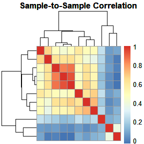

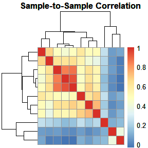

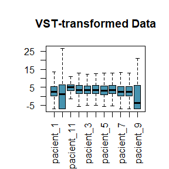

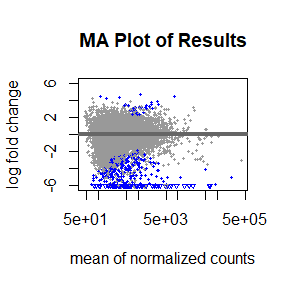

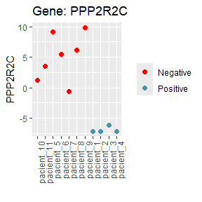

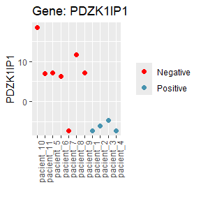

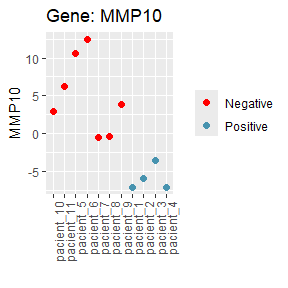

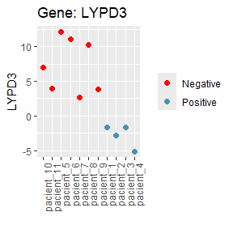

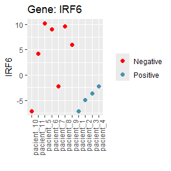

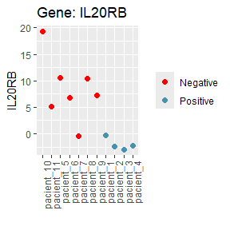

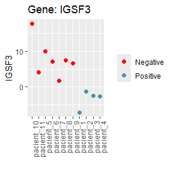

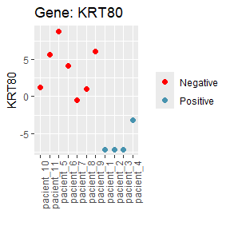

[1 more figures not shown]

```r
### DEA:
results <- HTG_DEA(outliers= NULL,
                   counts_data= counts_data_tutorial,
                   AnnotData_tutorial,
                   design_formula = "HPV_status",
                   heatmap_columns = c("HPV_status", "Recurrence"),
                   contrast = c("HPV_status", "Positive", "Negative"),
                   pattern = NULL,
                   remove_outliers = TRUE,
                   percentage_gene = 0.2,
                   threshold_gene = 200,
                   threshold_subject = 10,
                   pCutoff = 5e-2,
                   apply_filtering = TRUE,
                   apply_lfc_shrinkage = TRUE,
                   extract_shrinkage = FALSE)
```

```r
head(results)
```

```
#> log2 fold change (MLE): HPV_status Positive vs Negative
#> Wald test p-value: HPV status Positive vs Negative
#> DataFrame with 6 rows and 6 columns
#>         baseMean log2FoldChange     lfcSE      stat    pvalue      padj
#>        <numeric>      <numeric> <numeric> <numeric> <numeric> <numeric>
#> A4GALT  265.2319      -0.857765  0.972736 -0.881807  0.377881  0.884618
#> AAAS    242.5665       0.651080  1.093851  0.595218  0.551698  0.935195
#> AACS    192.2821      -0.461963  1.141883 -0.404563  0.685799  0.962334
#> AAGAB   516.7229       0.225376  1.069109  0.210808  0.833037  0.979764
#> AAK1    484.8080       0.747706  0.708205  1.055777  0.291070  0.834681
#> AAMDC    92.4109      -0.348642  1.276698 -0.273081  0.784791  0.975001
```

#### GSEA: GSEA() for RNAseq:

A GSEA analysis can be performed using the results from the DEA contrast. HTG_GSEA will generate plots and Excel files for easy interpretation.

```r
HTG_GSEA(res_tutorial)
```

[output not shown]

[output cut: 62 more lines]

[output not shown]

#### TME: HTG_TME () for RNAseq:

This function performs Tumor Microenvironment (TME) analysis, which will be stored in `TME_results`. You can access each method using `$`. This object contains results from three methodologies.

```r
TME_results<- HTG_TME(outliers= NULL,
                      pattern= NULL,
                      counts_data= counts_data_tutorial,
                      AnnotData= AnnotData_tutorial,
                      design_formula= "HPV_status",
                      remove_outliers = FALSE,
                      DEA = NULL)
```

```
#> [1] "Inicial gene number: 19612"
#> TPM normalization performed and stored on tpm_counts.csv
#> >>>--- This function is being optimised and we strongly recommend that you should set `source` as `local`....
#> [1] "Number of genes omitted during TPM normalization due to their length not being available in Biomart:   1292"
#> Performing normalization.
#>
#> >>> Running epic
#> Warning in (function (bulk, reference = NULL, mRNA_cell = NULL, mRNA_cell_sub = NULL, : The optimization didn't fully converge for some samples:
#> pacient_1
#>  - check fit.gof for the convergeCode and convergeMessage
#>
#> >>> Running quantiseq
#>
#> Running quanTIseq deconvolution module
#> Gene expression normalization and re-annotation (arrays: FALSE)
#> Removing 17 noisy genes
#> Removing 15 genes with high expression in tumors
#> Signature genes found in data set: 132/138 (95.65%)
#> Mixture deconvolution (method: lsei)
#> Deconvolution successful!
#>
#> >>> Running xcell
#> results of the devonvolution will be stored in imm_epic.csv, imm_qti.csv and imm_xcell.csv
#> Are they in the same order?
#> Have to be true.
#> EPIC
#> [1] TRUE
#> qti
#> [1] TRUE
#> xcell
#> [1] TRUE
#> Attention: plot_cell_fraction_Average_cell_fraction will work for all methods. For xCell, it will display Enrichment Scores instead of percentages.
#> Apply the filtering and normality test for each dataset
#> Checking if All Values in Each Column Are Equal in dataset: quanTIseq
#> In dataset quanTIseq the following columns have the same value in all rows and will be excluded from the analysis:
#> character(0)
#> Checking if All Values in Each Column Are Equal in dataset: EPIC
#> In dataset EPIC the following columns have the same value in all rows and will be excluded from the analysis:
#> character(0)
#> Checking if All Values in Each Column Are Equal in dataset: xcell
```

[output cut: 73 more lines]

```
#>    Cell_Type                        Test   p.value
#>    <chr>                            <chr>    <dbl>
#>  1 Myeloid_dendritic_cell_activated t-test 0.261
#>  2 B_cell                           t-test 0.0117
#>  3 T_cell_CD4+_memory               t-test 0.0824
#>  4 T_cell_CD4+_naive                t-test 0.138
#>  5 T_cell_CD4+_(non-regulatory)     t-test 0.391
#>  6 T_cell_CD4+_central_memory       t-test 0.718
#>  7 T_cell_CD4+_effector_memory      t-test 0.221
#>  8 T_cell_CD8+_naive                t-test 0.0158
#>  9 T_cell_CD8+                      t-test 0.00620
#> 10 T_cell_CD8+_central_memory       t-test 0.00861
#> # ℹ 29 more rows
#> GENERATING HEATMAPS
#> Heatmap of qti, EPIC and xcell will be stored on plots_TME_heatmap.pdf
```

```r
head(TME_results$EPIC)
```

```
#>                  B_cell Cancer_associated_fibroblast  T_cell_CD4+  T_cell_CD8+
#> pacient_1  5.761816e-05                  0.003052048 2.809917e-05 1.221264e-03
#> pacient_10 1.860627e-02                  0.002003424 3.348050e-02 1.250430e-08
#> pacient_11 2.153943e-02                  0.002687721 3.718262e-02 3.365694e-02
#> pacient_2  1.127895e-01                  0.021125917 1.515644e-01 1.117063e-03
#> pacient_3  1.758846e-01                  0.007868662 7.184744e-02 2.618624e-07
#> pacient_4  1.432281e-01                  0.055977750 4.910112e-07 9.659187e-07
#>            Endothelial_cell  Macrophage      NK_cell uncharacterized_cell
#> pacient_1       0.091888080 0.902395200 0.0013428550         1.479153e-05
#> pacient_10      0.006814236 0.016243050 0.0076642840         9.151882e-01
#> pacient_11      0.048973346 0.005869454 0.0017449610         8.483455e-01
#> pacient_2       0.014706200 0.037176220 0.0005302127         6.609905e-01
#> pacient_3       0.039574030 0.105800200 0.0011617810         5.978630e-01
#> pacient_4       0.010335500 0.330519500 0.0425455000         4.173922e-01
#>            HPV_status
#> pacient_1    Positive
#> pacient_10   Negative
#> pacient_11   Negative
#> pacient_2    Positive
#> pacient_3    Positive
#> pacient_4    Positive
```

```r
head(TME_results$QTI)
```

```
#>                B_cell Macrophage_M1 Macrophage_M2     Monocyte Neutrophil
#> pacient_1  0.06068186  0.000000e+00   0.467384548 0.0339131430          0
#> pacient_10 0.00000000  4.657421e-06   0.008676716 0.0000000000          0
#> pacient_11 0.10968111  2.789967e-02   0.258272590 0.0419024600          0
#> pacient_2  0.12234681  2.680036e-02   0.088367600 0.0107565000          0
#> pacient_3  0.11848900  5.281538e-03   0.337461954 0.0632290710          0
#> pacient_4  0.05787583  1.246982e-01   0.216806203 0.0002732752          0
#>                NK_cell T_cell_CD4+_(non-regulatory) T_cell_CD8+
#> pacient_1  0.009180179                   0.00000000  0.06056213
#> pacient_10 0.000000000                   0.00000000  0.00000000
#> pacient_11 0.055401760                   0.00000000  0.00000000
#> pacient_2  0.000000000                   0.30387010  0.03345475
#> pacient_3  0.012099214                   0.07237622  0.05779969
#> pacient_4  0.048886356                   0.00000000  0.16270461
#>            T_cell_regulatory_(Tregs) Myeloid_dendritic_cell
#> pacient_1                0.023276671                      0
#> pacient_10               0.074193660                      0
#> pacient_11               0.077387280                      0
#> pacient_2                0.126769820                      0
#> pacient_3                0.109147133                      0
#> pacient_4                0.007422653                      0
#>            uncharacterized_cell HPV_status
#> pacient_1             0.3450015   Positive
#> pacient_10            0.9171250   Negative
#> pacient_11            0.4294551   Negative
#> pacient_2             0.2876341   Positive
#> pacient_3             0.2241162   Positive
#> pacient_4             0.3813328   Positive
```

```r
head(TME_results$XCELL)
```

```
#>            Myeloid_dendritic_cell_activated      B_cell T_cell_CD4+_memory
#> pacient_1                      3.643636e-02 0.325817000       1.155561e-01
#> pacient_10                     0.000000e+00 0.069898760       0.000000e+00
#> pacient_11                     7.506179e-18 0.004710779       1.314932e-18
#> pacient_2                      0.000000e+00 0.465687400       3.341689e-01
#> pacient_3                      1.122156e-02 0.502361900       2.320889e-01
#> pacient_4                      6.505701e-18 0.209267200       5.391349e-02
#>            T_cell_CD4+_naive T_cell_CD4+_(non-regulatory)
#> pacient_1       5.090119e-02                 5.561708e-18
#> pacient_10      2.723449e-17                 0.000000e+00
#> pacient_11      8.763171e-17                 0.000000e+00
#> pacient_2       1.171166e-01                 7.908145e-02
#> pacient_3       3.727335e-02                 0.000000e+00
#> pacient_4       5.710173e-20                 1.926550e-17
#>            T_cell_CD4+_central_memory T_cell_CD4+_effector_memory
#> pacient_1                1.457607e-17                1.133075e-17
#> pacient_10               4.423745e-18                1.346417e-18
#> pacient_11               0.000000e+00                0.000000e+00
#> pacient_2                2.728989e-02                1.829296e-01
#> pacient_3                3.222174e-03                2.035328e-01
#> pacient_4                1.008337e-17                0.000000e+00
#>            T_cell_CD8+_naive T_cell_CD8+ T_cell_CD8+_central_memory
#> pacient_1         0.03982396  0.08644197               5.192928e-02
#> pacient_10        0.00000000  0.00000000               0.000000e+00
#> pacient_11        0.00000000  0.00000000               2.374619e-17
#> pacient_2         0.08866323  0.18235810               1.120451e-01
#> pacient_3         0.08616155  0.16630400               8.208015e-02
#> pacient_4         0.07929292  0.14778870               6.858534e-02
#>            T_cell_CD8+_effector_memory Class-switched_memory_B_cell
#> pacient_1                 4.812152e-02                 6.880728e-02
#> pacient_10                2.347553e-18                 4.671174e-18
#> pacient_11                0.000000e+00                 0.000000e+00
#> pacient_2                 1.481820e-01                 1.557426e-01
#> pacient_3                 1.164781e-01                 1.653161e-01
#> pacient_4                 1.317805e-01                 6.432809e-02
#>            Common_lymphoid_progenitor Common_myeloid_progenitor
#> pacient_1                8.967202e-03              0.000000e+00
#> pacient_10               2.752829e-18              2.454706e-17
#> pacient_11               2.239888e-02              3.096710e-01
#> pacient_2                3.881367e-02              1.808654e-18
```

[output cut: 43 more lines]

```
#> pacient_4        0.000000e+00      0.37364330    7.093965e-18
#>            T_cell_regulatory_(Tregs) immune_score stroma_score
#> pacient_1               2.899365e-18   0.35597630 0.0006717287
#> pacient_10              1.778618e-02   0.09371044 0.0000000000
#> pacient_11              0.000000e+00   0.05837260 0.0295743600
#> pacient_2               0.000000e+00   0.52842900 0.0077734710
#> pacient_3               4.011460e-18   0.54226040 0.0347255100
#> pacient_4               1.063329e-17   0.29092590 0.0226146700
#>            microenvironment_score HPV_status
#> pacient_1              0.35664800   Positive
#> pacient_10             0.09371044   Negative
#> pacient_11             0.08794696   Negative
#> pacient_2              0.53620240   Positive
#> pacient_3              0.57698590   Positive
#> pacient_4              0.31354060   Positive
```

#### Survival analysis: HTG_survival() for RNAseq:

Survival analysis can be performed using the results from DEA (res), specific genes, or TME results. The function prioritizes inputs: first genes_to_use, then DEA results, and finally TME results if none are provided.

```r
###### survival using res
 HTG_survival(variable_01 = "Recurrence_01",
              time = "Time_to_death_surv",
              col_data = AnnotData_tutorial,
              counts_data = counts_data_tutorial,
              res = res_tutorial, #DEA results.
              genes_to_use = NULL,
              outliers = NULL,
              pattern = NULL,
              remove_outliers = FALSE)
```

```
#> Normalizing data...
#> OBTAINING NORMALIEZ COUNTS...
#> Checking for duplicate columns
#> [1] "No duplicate columns."
#> Filtering data.
#> Selecting TOP 10 genes with the lowest padj
#> Starting survival analysis.
#>
#> Performing analysis for column:  LCP1
#> CUT OFF
#> estimated cutpoint
#>           436.3411
#> Fitting survival model
#> Summary of the fit
#> Call: survfit(formula = surv_formula, data = merged_data)
#>
#>                 LCP1_mRNA_expression=High
#>  time n.risk n.event survival std.err lower 95% CI upper 95% CI
#>  1164      5       1      0.8   0.179        0.516            1
#>  1287      4       1      0.6   0.219        0.293            1
#>  5844      1       1      0.0     NaN           NA           NA
#>
#>                 LCP1_mRNA_expression=Low
#>  time n.risk n.event survival std.err lower 95% CI upper 95% CI
#>   234      4       1     0.75   0.217        0.426            1
#>  2458      1       1     0.00     NaN           NA           NA
#>
#> Performing log-rank test and obtaining p-value
#> Call:
#> survival::survdiff(formula = surv_formula, data = merged_data)
#>
#>                           N Observed Expected (O-E)^2/E (O-E)^2/V
#> LCP1_mRNA_expression=High 7        3     3.77     0.157     0.759
#> LCP1_mRNA_expression=Low  4        2     1.23     0.482     0.759
#>
#>  Chisq= 0.8  on 1 degrees of freedom, p= 0.4
#> P-value
#> [1] 0.3835652
#> Generating Kaplan-Meier plot
#> Plots saved in survival_analysis_plots_top_10.pdf
```

[output cut: 251 more lines]

```
#> Performing log-rank test and obtaining p-value
#> Call:
#> survival::survdiff(formula = surv_formula, data = merged_data)
#>
#>                              N Observed Expected (O-E)^2/E (O-E)^2/V
#> TACSTD2_mRNA_expression=High 6        2    4.012      1.01      6.42
#> TACSTD2_mRNA_expression=Low  5        3    0.988      4.10      6.42
#>
#>  Chisq= 6.4  on 1 degrees of freedom, p= 0.01
#> P-value
#> [1] 0.01125371
#> Generating Kaplan-Meier plot
#> Plots saved in survival_analysis_plots_top_10.pdf
#> png
#>   2
```

```r
###### survival using genes to use
 HTG_survival(variable_01 = "Recurrence_01",
              time = "Time_to_death_surv",
              col_data = AnnotData_tutorial,
              counts_data = counts_data_tutorial,
              res = NULL,
              genes_to_use = c("LCP1", "OMA1"),
              outliers = NULL,
              pattern = NULL,
              remove_outliers = FALSE)
```

```
#> Normalizing data...
#> OBTAINING NORMALIEZ COUNTS...
#> Checking for duplicate columns
#> [1] "No duplicate columns."
#> Filtering data.
#> Using provided genes
#> Starting survival analysis.
#>
#> Performing analysis for column:  LCP1
#> CUT OFF
#> estimated cutpoint
#>           436.3411
#> Fitting survival model
#> Summary of the fit
#> Call: survfit(formula = surv_formula, data = merged_data)
#>
#>                 LCP1_mRNA_expression=High
#>  time n.risk n.event survival std.err lower 95% CI upper 95% CI
#>  1164      5       1      0.8   0.179        0.516            1
#>  1287      4       1      0.6   0.219        0.293            1
#>  5844      1       1      0.0     NaN           NA           NA
#>
#>                 LCP1_mRNA_expression=Low
#>  time n.risk n.event survival std.err lower 95% CI upper 95% CI
#>   234      4       1     0.75   0.217        0.426            1
#>  2458      1       1     0.00     NaN           NA           NA
#>
#> Performing log-rank test and obtaining p-value
#> Call:
#> survival::survdiff(formula = surv_formula, data = merged_data)
#>
#>                           N Observed Expected (O-E)^2/E (O-E)^2/V
#> LCP1_mRNA_expression=High 7        3     3.77     0.157     0.759
#> LCP1_mRNA_expression=Low  4        2     1.23     0.482     0.759
#>
#>  Chisq= 0.8  on 1 degrees of freedom, p= 0.4
#> P-value
#> [1] 0.3835652
#> Generating Kaplan-Meier plot
#> Plots saved in survival_analysis_plots_SELECTED_GENES.pdf
```

[output cut: 20 more lines]

```
#> Performing log-rank test and obtaining p-value
#> Call:
#> survival::survdiff(formula = surv_formula, data = merged_data)
#>
#>                           N Observed Expected (O-E)^2/E (O-E)^2/V
#> OMA1_mRNA_expression=High 5        2    0.988     1.037      1.63
#> OMA1_mRNA_expression=Low  6        3    4.012     0.255      1.63
#>
#>  Chisq= 1.6  on 1 degrees of freedom, p= 0.2
#> P-value
#> [1] 0.202311
#> Generating Kaplan-Meier plot
#> Plots saved in survival_analysis_plots_SELECTED_GENES.pdf
#> png
#>   2
```

```r
###### survival using TME data.
HTG_survival(variable_01 = "Recurrence_01",
              time = "Time_to_death_surv",
              col_data = AnnotData_tutorial,
              counts_data = counts_data_tutorial,
              res = NULL,
              genes_to_use = NULL,
              TME = TME_data_tutorial$EPIC,
              outliers = NULL,
              pattern = NULL,
              remove_outliers = FALSE)
```

```
#> Normalizing data...
#> OBTAINING NORMALIEZ COUNTS...
#> Checking for duplicate columns
#> [1] "No duplicate columns."
#> Filtering data.
#> Using rownames from TME
#> Starting survival analysis.
#>
#> Performing analysis for column:  B_cell
#> CUT OFF
#> estimated cutpoint
#>         0.01481276
#> Fitting survival model
#> Summary of the fit
#> Call: survfit(formula = surv_formula, data = merged_data)
#>
#>                 B_cell=High
#>  time n.risk n.event survival std.err lower 95% CI upper 95% CI
#>  1164      2       1      0.5   0.354        0.125            1
#>  2458      1       1      0.0     NaN           NA           NA
#>
#>                 B_cell=Low
#>  time n.risk n.event survival std.err lower 95% CI upper 95% CI
#>  1287      4       1     0.75   0.217        0.426            1
#>  5844      1       1     0.00     NaN           NA           NA
#>
#> Performing log-rank test and obtaining p-value
#> Call:
#> survival::survdiff(formula = surv_formula, data = merged_data)
#>
#>             N Observed Expected (O-E)^2/E (O-E)^2/V
#> B_cell=High 4        2     1.03     0.904      1.48
#> B_cell=Low  4        2     2.97     0.315      1.48
#>
#>  Chisq= 1.5  on 1 degrees of freedom, p= 0.2
#> P-value
#> [1] 0.2240827
#> Generating Kaplan-Meier plot
#> Plots saved in survival_analysis_plots_TME.pdf
#>
```

[output cut: 218 more lines]

```
#> Performing log-rank test and obtaining p-value
#> Call:
#> survival::survdiff(formula = surv_formula, data = merged_data)
#>
#>                           N Observed Expected (O-E)^2/E (O-E)^2/V
#> uncharacterized_cell=High 5        2      3.1      0.39      2.47
#> uncharacterized_cell=Low  3        2      0.9      1.34      2.47
#>
#>  Chisq= 2.5  on 1 degrees of freedom, p= 0.1
#> P-value
#> [1] 0.1160831
#> Generating Kaplan-Meier plot
#> Plots saved in survival_analysis_plots_TME.pdf
#> png
#>   2
```